# Replication of COmmunity-Based Fact-Checking on Twitter’s Birdwatch Platform

## Loading notes and ratings

```r
# Loading notes and ratings data from data folder
notes <- read_tsv("./data/notes.tsv")
ratings <- read_tsv("./data/ratings.tsv")
```

In notes, there are 9377 rows and in ratings, there are 45885 rows.

## Figure 2 Plot

Number of users who responded “Yes” to the question “Did you link to sources you believe most people would consider trustworthy?”

```r
# convert to a datetime format from milliseconds
notes <- notes |>
    mutate(datetime = as.POSIXct(createdAtMillis / 1000, origin = "1970-01-01", tz = "UTC"))
# making is_misleading columns based on the columns that starts with misleading
notes <- notes |>
    mutate(is_misleading = (misleadingOther == 1 | misleadingFactualError == 1 | misleadingManipulatedMedia ==1 | misleadingOutdatedInformation ==1 | misleadingMissingImportantContext == 1 | misleadingUnverifiedClaimAsFact == 1 | misleadingSatire == 1 ) )
# making is_notmisleading columns based on the columns that starts with notMisleading
notes <- notes |>
     mutate(is_notmisleading = (notMisleadingOther ==1 | notMisleadingFactuallyCorrect==1 | notMisleadingOutdatedButNotWhenWritten == 1 | notMisleadingClearlySatire==1 | notMisleadingPersonalOpinion ==1))
```

[figure not shown]

```r
# making trustworthySources as a categorical value
notes$trustworthySources <- as.factor(notes$trustworthySources)

labels <- c("Misleading", "Not Misleading")
# making the figure 2 plot
ggplot(notes, aes(x = is_misleading, fill = trustworthySources)) +
  geom_bar(stat = "count", position = "stack") +
  coord_flip() +
  theme(legend.title = element_blank()) +
  theme(axis.title = element_blank()) +
  scale_x_discrete(label = labels) +
  scale_fill_manual(labels=c("No trustworthy sources", "trustworthy sources"), values = c("yellow", "blue"))
```

# Figure 3 Plot

Number of Birdwatch notes per checkbox answer option in response to the question “Why do you believe this tweet may be misleading?”

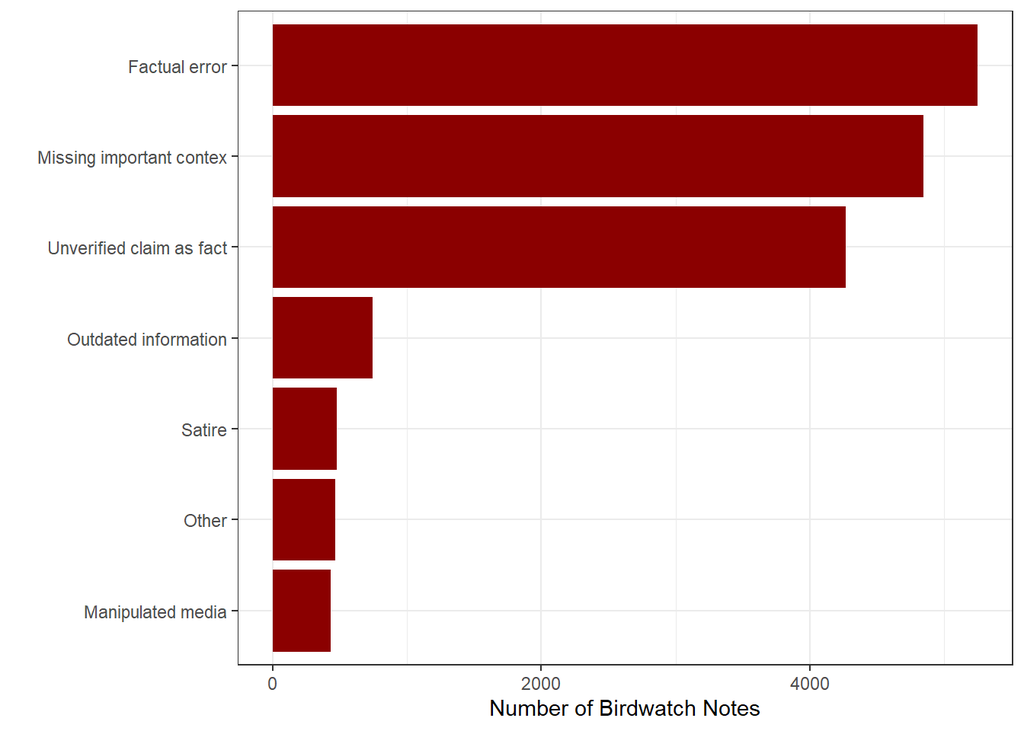

```r
notes |>
    select("misleadingOther", "misleadingFactualError", "misleadingManipulatedMedia", "misleadingOutdatedInformation","misleadingMissingImportantContext", "misleadingUnverifiedClaimAsFact", "misleadingSatire")  |>
    # rename column names so that it appears nicely on the graph
    rename("Other" = "misleadingOther", "Factual error" = "misleadingFactualError", "Manipulated media" = "misleadingManipulatedMedia", "Outdated information" = "misleadingOutdatedInformation", "Missing important contex" = "misleadingMissingImportantContext", "Unverified claim as fact" = "misleadingUnverifiedClaimAsFact", "Satire" = "misleadingSatire")|>
    # since the columns are 1 and 0, add all the value in the columns to get how many are one or true.
    colSums() |>
    tibble::enframe(name = "category", value = "total_count") |>
    ggplot(aes(y =reorder(category, total_count, FUN = sum, decreasing = FALSE), x = total_count)) +
    geom_bar(stat = "identity", fill="darkred") +
    xlab("Number of Birdwatch Notes") +
    ylab("") +
    scale_x_continuous(breaks = seq(0, 5500, by = 2000))
```

## Figure 4 Plot

Number of Birdwatch notes per checkbox answer option in response to the question “Why do you believe this tweet is not misleading?”

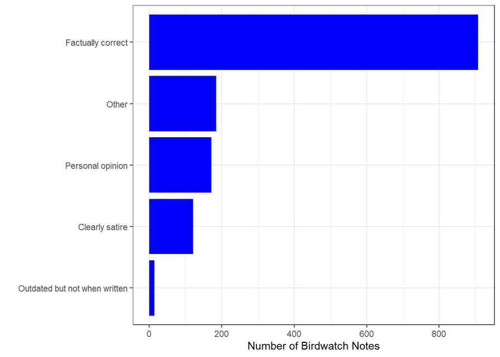

```r
notes |>
  select("notMisleadingOther", "notMisleadingFactuallyCorrect", "notMisleadingOutdatedButNotWhenWritten","notMisleadingClearlySatire", "notMisleadingPersonalOpinion") |>
  rename("Other" = "notMisleadingOther", "Factually correct" = "notMisleadingFactuallyCorrect", "Outdated but not when written" = "notMisleadingOutdatedButNotWhenWritten", "Clearly satire" = "notMisleadingClearlySatire", "Personal opinion" = "notMisleadingPersonalOpinion") |>
  colSums() |>
  tibble::enframe(name = "category", value = "total_count") |>
  ggplot(aes(y =reorder(category, total_count, FUN = sum, decreasing = FALSE), x = total_count)) +
  geom_bar(stat = "identity", fill="blue") +
  xlab("Number of Birdwatch Notes") +
  ylab("") +
  scale_x_continuous(breaks = seq(0, 1000, by = 200))
```

## Figure 5c Plot

CCDFs for word count in text explanations of Birdwatch notes.

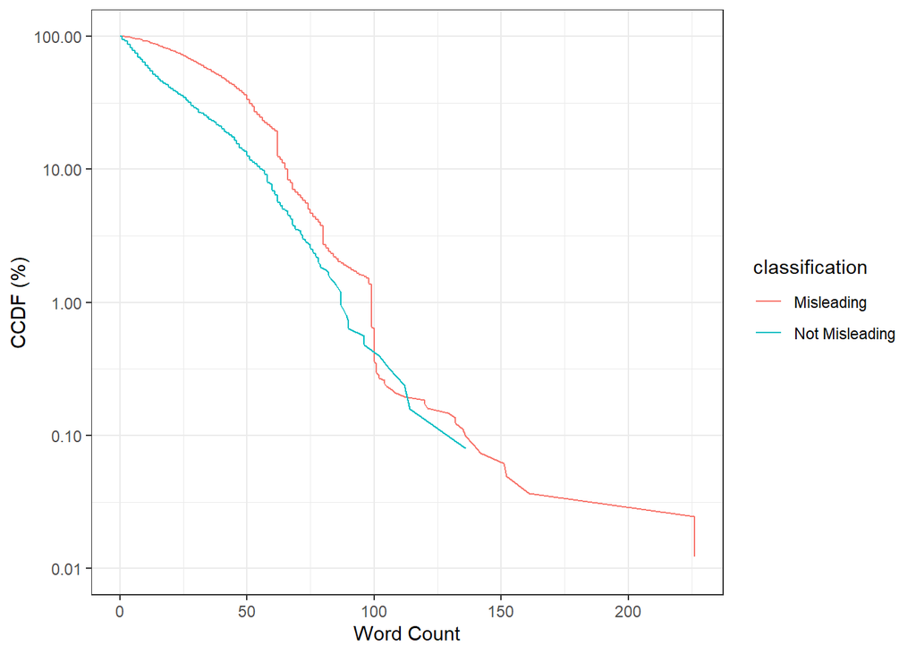

```r
# generating word count from summary (add noteId and trustworthySources for the usage of plot 10)
notes_classification_word_count <- notes |>
  # we don't know excatly how author counts the words or what text mining pipeline he use
  # so, we just use str_count from tidyverse library and we get similar results
  mutate(word_count = str_count(summary, '\\w+')) |>
  select(noteId, classification, word_count, trustworthySources) |>
  # rename misleading and not misleading to appear nice in the plot
  mutate(classification = case_when(
    classification == "MISINFORMED_OR_POTENTIALLY_MISLEADING" ~ "Misleading",
    classification == "NOT_MISLEADING" ~ "Not Misleading"
  ))

notes_classification_word_count |>
  drop_na(word_count) |>
  group_by(classification) |>
  arrange(word_count) |>
  # Calculate CCDF using the rank of each note
  mutate(n = n(),
         rank = row_number(),
         ccdf_percent = (1 - (rank - 1) / n) * 100) |>
  filter(ccdf_percent > 0) |>
  ggplot(aes(x = word_count, y = ccdf_percent, color = classification)) +
  geom_line() +
  scale_y_log10(limits = c(0.01, 100), label=scales::comma) +
  labs(
    x = "Word Count",
    y = "CCDF (%)"
  )
```

## Figure 7(a and b) Plots

CCDFs for (a) helpfulness ratio and (b) total votes.

Figure 7a

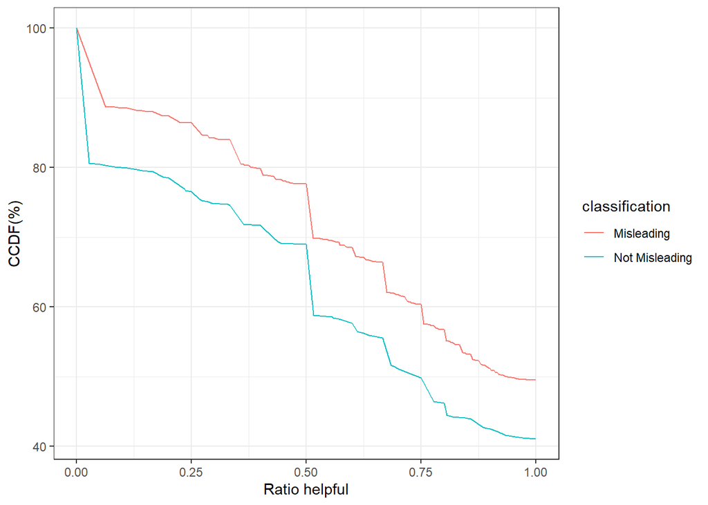

```r
# find the total number of helpful and not helpful and find the helpfulness ratio
ratings_2 <- ratings |>
    group_by(noteId) |>
    summarize(total_helpful = sum(helpful), total_unhelpful = sum(notHelpful)) |>
    mutate(total=total_helpful + total_unhelpful, ratio_helpful = total_helpful/total)
# find the ccdf percent using rank method
ccdf_ratio <- inner_join(notes, ratings_2, by="noteId") |>
    mutate(classification = case_when(
        classification == "MISINFORMED_OR_POTENTIALLY_MISLEADING" ~ "Misleading",
        classification == "NOT_MISLEADING" ~ "Not Misleading"
    )) |>
    group_by(classification) |>
    arrange(ratio_helpful) |>
    mutate(rank = min_rank(ratio_helpful),
           n = n(),
           ccdf = (1 - ((rank - 1) / n)) * 100) |>
    filter(ccdf != "Invalid Number")

ggplot(ccdf_ratio, aes(x=ratio_helpful, y=ccdf, color=classification)) +
    geom_line() +
    xlab("Ratio helpful") +
    ylab("CCDF(%)")
```

Figure 7b

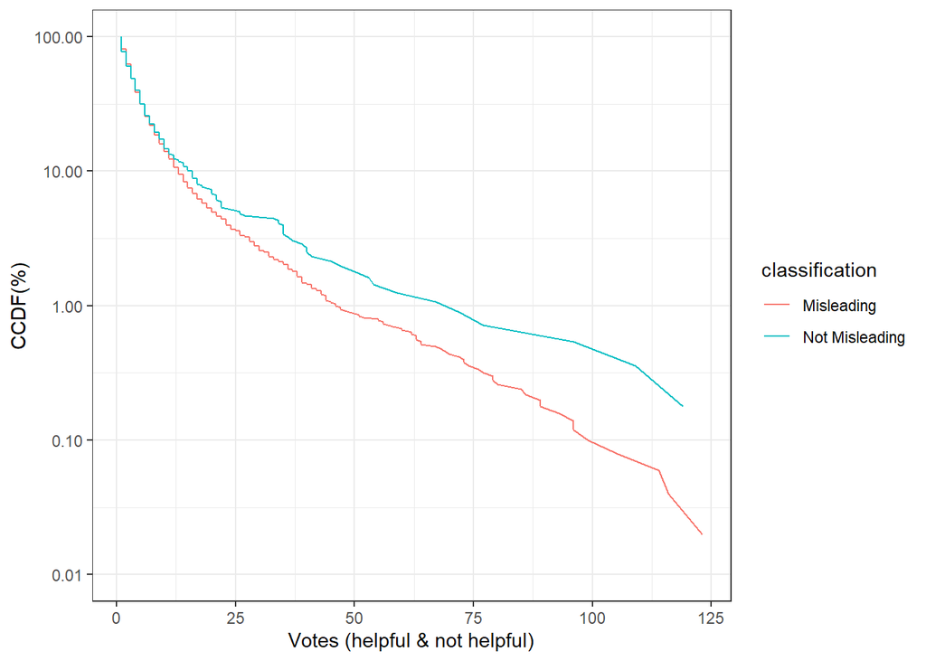

```r
ratings_with_votes_per_note <- ratings |>
  select(noteId) |>
  group_by(noteId) |>
  summarize(votes_per_note = n())


joined_raings_notes <- inner_join(notes, ratings_with_votes_per_note, by = "noteId")

joined_raings_notes |>
  select(classification, votes_per_note) |>
  mutate(classification = case_when(
    classification == "MISINFORMED_OR_POTENTIALLY_MISLEADING" ~ "Misleading",
    classification == "NOT_MISLEADING" ~ "Not Misleading"
  )) |>
  group_by(classification) |>
  arrange(votes_per_note) |>
  mutate(n = n(),
         rank = row_number(),
         ccdf_percent = (1 - (rank - 1) / n) * 100) |>
  ggplot(aes(x = votes_per_note, y = ccdf_percent, color = classification)) +
  geom_line() +
  scale_y_log10(limits = c(0.01, 100), label=scales::comma) +
  xlab("Votes (helpful & not helpful)") +
  ylab("CCDF(%)")
```

## Figure 8 Plot Number of ratings per checkbox answer option in response to the prompt “What about this note was helpful to you?”

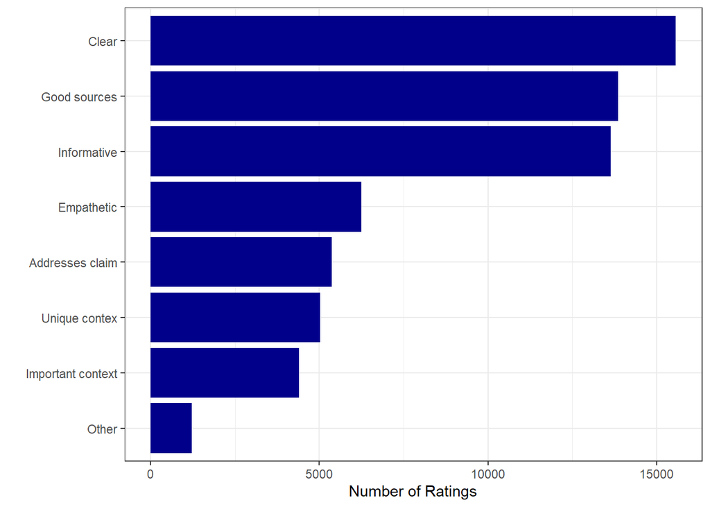

```r
# doesn't include Unbiased language as no one chooses this opiton
ratings |>
    select("helpfulOther", "helpfulInformative", "helpfulClear", "helpfulEmpathetic", "helpfulGoodSources", "helpfulUniqueContext", "helpfulAddressesClaim", "helpfulImportantContext")  |>
    rename("Other" = "helpfulOther", "Informative" = "helpfulInformative", "Clear" = "helpfulClear", "Empathetic" = "helpfulEmpathetic", "Good sources" = "helpfulGoodSources", "Unique contex" = "helpfulUniqueContext", "Addresses claim" = "helpfulAddressesClaim", "Important context" = "helpfulImportantContext")|>
    colSums() |>
    tibble::enframe(name = "category", value = "total_count") |>
    ggplot(aes(y =reorder(category, total_count, FUN = sum, decreasing = FALSE), x = total_count)) +
    geom_bar(stat = "identity", fill="darkblue") +
    xlab("Number of Ratings") +
    ylab("") +
    scale_x_continuous(breaks = seq(0, 16000, by = 5000))
```

## Figure 9 Plot

Number of ratings per checkbox answer option in response to the question “Help us understand why this note was unhelpful.”

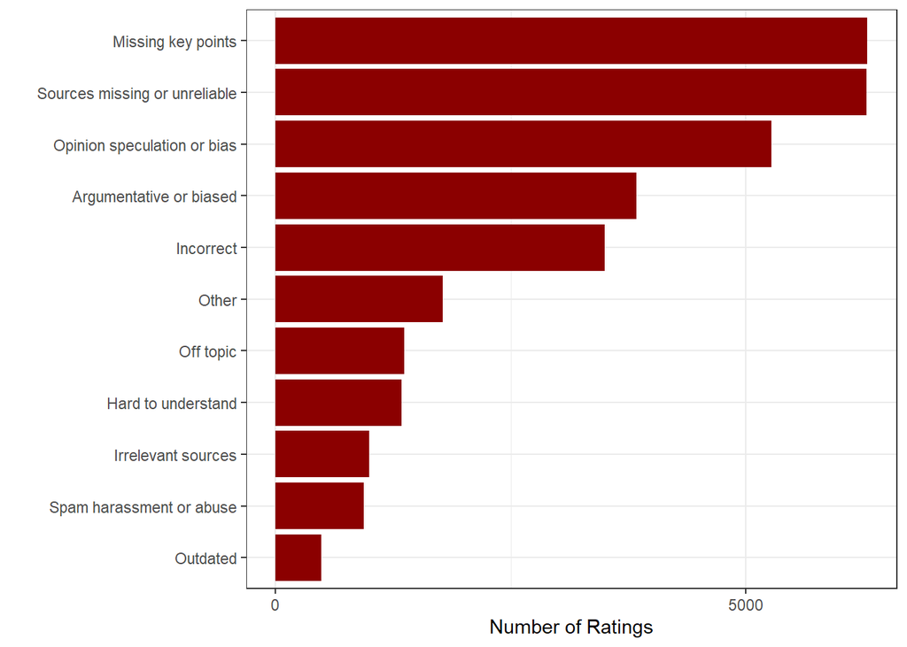

```r
# notHelpfulOpinionSpeculation is not included because no one chooses this option
# here we use string methods to formate the column names
ratings |>
    select("notHelpfulOther", "notHelpfulIncorrect", "notHelpfulSourcesMissingOrUnreliable", "notHelpfulOpinionSpeculationOrBias", "notHelpfulMissingKeyPoints", "notHelpfulOutdated", "notHelpfulHardToUnderstand", "notHelpfulArgumentativeOrBiased", "notHelpfulOffTopic", "notHelpfulSpamHarassmentOrAbuse", "notHelpfulIrrelevantSources")  |>
     rename_with(~ .x |>
    str_remove("notHelpful") |>
    str_replace_all("([A-Z])", " \\1") |>
    str_to_sentence()
      ) |>
    colSums() |>
    tibble::enframe(name = "category", value = "total_count") |>
    ggplot(aes(y =reorder(category, total_count, FUN = sum, decreasing = FALSE), x = total_count)) +
    geom_bar(stat = "identity", fill="darkred") +
    xlab("Number of Ratings") +
    ylab("") +
    scale_x_continuous(breaks = seq(0, 16000, by = 5000))
```

## Figure 10 Plot

```r
# loading source tweets from the data folder
source_tweets <- get(load("./data/source_tweets.Rdata"))
```

```r
#misleading
  #classification in notes_classification_word_count
#trustworthy sources
  #trustworthySources in notes
#text complexity -- not required
#sentiment -- not required
#word count
  #in notes_classification_word_count
#account age
  #source_account_created_at in source_tweets
#followers
  #source_followers_count in source_tweets
#followees
  #source friend count in source_tweets
#verified
  #source_verified in source_tweets

logit_reg_df <- ratings |> select(noteId, helpful)
source_tweets_2 <- source_tweets |> select(noteId, source_account_created_at, source_followers_count, source_friends_count, source_verified )
logit_reg_df <- inner_join(logit_reg_df, source_tweets_2, by="noteId")
logit_reg_df <- inner_join(logit_reg_df, notes_classification_word_count)
#rename to misleading
logit_reg_df <- logit_reg_df |> rename(misleading = classification, verified = source_verified, followees = source_friends_count)
#take source_account_created_at and make it age
current_date <- Sys.Date()
current_year <- format(current_date, "%Y")
logit_reg_df <- logit_reg_df |> mutate(account_age = as.numeric(current_year) - as.numeric(year(logit_reg_df$source_account_created_at)))
#drop na from all of them esp in source_tweets
logit_reg_df <- drop_na(logit_reg_df)

#made misleading into a binary variable
logit_reg_df <- logit_reg_df |> mutate(misleading = if_else(misleading == "Misleading", 1, 0, ))
#zstandardize all features
logit_reg_df <- logit_reg_df |> mutate(across(c(source_followers_count,followees,word_count,account_age), scale))

# fitting the model
model <- glm(helpful ~ misleading + trustworthySources + word_count + account_age + followees + source_followers_count + verified, data=logit_reg_df, family=binomial)
tidy(model)
```

```
## # A tibble: 8 × 5
##   term                   estimate std.error statistic  p.value
##   <chr>                     <dbl>     <dbl>     <dbl>    <dbl>
## 1 (Intercept)             -0.499     0.0502     -9.94 2.80e-23
## 2 misleading               0.517     0.0386     13.4  6.37e-41
## 3 trustworthySources1      0.338     0.0286     11.8  3.41e-32
## 4 word_count               0.151     0.0132     11.4  4.54e-30
## 5 account_age              0.116     0.0123      9.38 6.41e-21
## 6 followees               -0.0479    0.0126     -3.81 1.42e- 4
## 7 source_followers_count   0.0126    0.0123      1.03 3.03e- 1
## 8 verifiedTRUE            -0.412     0.0363    -11.3  8.27e-30
```

```r
#add predictions to data for plotting
logit_reg_df <- logit_reg_df |> mutate(predicted_prob = predict(model, type="response"))
```

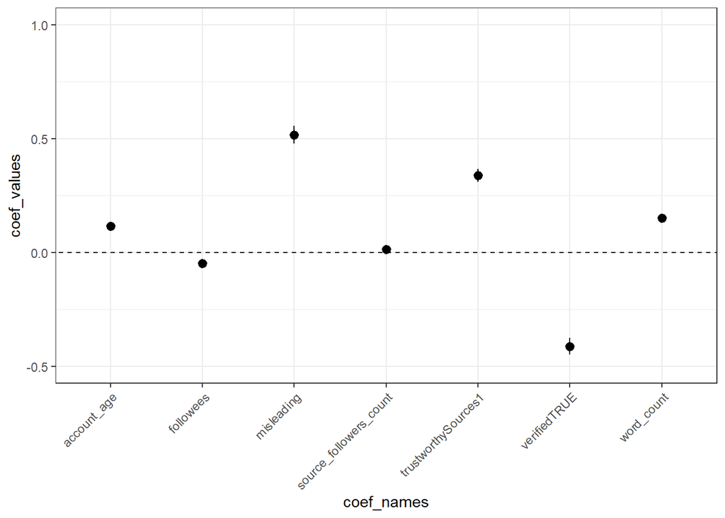

```r
# get the estimate and std error from the model
coef_values <- coef(summary(model))[, "Estimate"]
se_vector <- summary(model)$coefficients[, "Std. Error"]
coef_values <- coef_values[-1]
se_vector <- se_vector[-1]
coef_names <- names(coef(model))
coef_names <- coef_names[-1]

plot_data <- data.frame(coef_names, coef_values, se_vector)
ggplot(plot_data, aes(x=coef_names, y=coef_values)) +
  geom_pointrange(aes(ymin=coef_values - se_vector, ymax=coef_values + se_vector)) +
  scale_y_continuous(limits = c(-0.5, 1)) +
  geom_abline(slope = 0, intercept = 0, linetype = "dashed") +
  theme(axis.text.x = element_text(angle = 45, hjust = 1))
```

# Extensions/ Question 4 Answer

1. From here think about extensions to the article. Could you have approached this problem differently with the same data? Are there other ways to plot the same information? Or can you reproduce a version of the Birdwatch algorithm from [this paper](https://arxiv.org/pdf/2210.15723)? Each group will probably come up with different questions to ask of the data. Write down the questions your group is interested in along with a plan for how you can tackle them with the data you have.

original paper research questions – specific reasons someone writes a note? how do misleading and nonmisleading notes differ in sentiment text characteristics — level of consensus among users associated with social influence of the author of the source tweet . — what characteristics of birdwatch notes are associated with being more helpful to raters

the original findings of the paper – Users more frequently file birdwatch notes for misleading than not misleading tweets, birdwatch notes are more helpful to tohher users if they link to trustworthy sources and use a positive sentiment. AND the social influence of the author is associated with differences in the lelvel of user consensus. for influential users less oncsensus incorrect and argumentative.

#### What We Did Differently and Why It May Be Better

why are we doing log reg to predict a continous value ?

so in our figure 10 on the logisitc regression, we predicted the probability that someone who filed a rating for the note voted helpful or not based on the characteristics of the source tweet and its author

the original regression is predicting the ratio of helpful:not helpful votes per note (not per rating) using the same features of the tweet and its author. I think our regression is more impactful in determining what makes someone vote helpful or not helpful in a note and further finds what makes a user more or less likely to agree with a note. this could allow us to include more detailed info on the rater themselves and attributes about their accoutn to see what type of person/account votes helpful or unhelpful

I think also a plot that talks about the characterisitcs of a note that users find helpful or not is more important than the questions asking why its helpgul because to me all these options in the poll “informative, clear, good sources, empathetic, unique context” are all vaguely the same like contains_url like the figure 5 plots but per rating….

#### Addiitonal Research Question

i guess a further research question could be to see if the notes affects how ppl tweets (twitter celebs + noncelebs who have gotten fact checked) do they correct their behavior, in Johnas presentation he talked about how notes terminates the spread of misinformation but does it change individual behavior and does it change the behavior of the tweeters or does it change other ppl who see them getting fact checked to prevent misinfo being posted in the first place

#### A Feature We Would Add To The Dataset

So a potential feature to Birdwatch to add that would provide more depth into the ratings system would be for each user to be able to see per note, the note author’s profile of previous notes they have written and if they have been marked helpful or unhelpful. so when a user is looking at a note and deciding to rate it or not, they can see if that note author is sus.

Now this could lead to some bias where a user who has posted contraversial notes before may now never get a note put thorugh because ppl are put off with their past note history instead of the current note they posted.

I guess this is just a guess this is just a heuristic but to me the only way to truly verify a tweet is real is to look at a source, not someone tweeting about the source or sharing their interpretation of the topic. so maybe we could use an llm (like grok) to summarize the source and see if it matches up with what the note says an extra check to see if the note is helpful or not? so u dont have to @ grok